# Machine Learning Using R Programming

Saraswathi Analytics

Email: info@saraswathianalytics.com

## R - Introduction

R is a programming language and software environment for statistical analysis, graphics representation and reporting. R was created by Ross Ihaka and Robert Gentleman at the University of Auckland, New Zealand, and is currently developed by the R Development Core Team. R is freely available under the GNU General Public License, and pre-compiled binary versions are provided for various operating systems like Linux, Windows and Mac. This programming language was named R, based on the first letter of first name of the two R authors (Robert Gentleman and Ross Ihaka), and partly a play on the name of the Bell Labs Language S.

```r
# Basic programming of Hello - Data Science...!
myString <- "Hello - Data Science...!"

print (myString) # print variable
```

```
## [1] "Hello - Data Science...!"
```

```r
myString <- "Hello, Saraswathi ANalytics"
print ( myString)  # Print variable
```

```
## [1] "Hello, Saraswathi ANalytics"
```

```r
## Comments in R programming
" Comments are like helping text within your R source code, and
these statements get ignored by the interpreter while running your actual program. "
```

```
## [1] " Comments are like helping text within your R source code, and\nthese statements get ignored by the interpreter while running your actual program. "
```

My first R programming is Hello Saraswathi Analytics

## R - Calculator

```r
35 + 65   # Addition
```

```
## [1] 100
```

```r
2020 - 2010   # Subtraction
```

```
## [1] 10
```

```r
24 * 25   # Multiplication
```

```
## [1] 600
```

```r
108 / 12   # Division
```

```
## [1] 9
```

```r
2 ^ 2  # squares or cubes or .... OR same as
```

```
## [1] 4
```

```r
2 ** 2
```

```
## [1] 4
```

```r
828 %% 20 # reminder
```

```
## [1] 8
```

## R - Data Types

Here is the list of all the data types provided by R:

1. Numeric
2. Integer
3. Complex
4. Logical
5. Character

```r
# 1. Numeric: Decimal values are referred to as numeric data types in R.
v <- 25.8 # assign decimal value to v

print(v) # print variable
```

```
## [1] 25.8
```

```r
print(class(v)) # print the variable values - v
```

```
## [1] "numeric"
```

```r
is.numeric(v)   # checking whether numeric or  not
```

```
## [1] TRUE
```

```r
numeric(length = 10) # creating 10 numeric values. Those are contains with zero's
```

```
##  [1] 0 0 0 0 0 0 0 0 0 0
```

```r
# 2. Integer: If you want to create a integer using as.integer() or ( use capital letter L after non decimal value)
v <- as.integer(32) # assign integer value to v
v1 <- 53L # assign integer value to v1

print(v) # print variable v
```

```
## [1] 32
```

```r
print(v1) # print variable v1
```

```
## [1] 53
```

```r
print(class(v)) # print the variable values - v
```

```
## [1] "integer"
```

```r
print(class(v1)) # print the variable values - v1
```

```
## [1] "integer"
```

```r
is.integer(v)   # checking whether integer or  not
```

```
## [1] TRUE
```

```r
is.integer(v1)   # checking whether integer or  not
```

```
## [1] TRUE
```

```r
integer(length = 10) # creating 10 integer values. Those are contains with zero's
```

```
##  [1] 0 0 0 0 0 0 0 0 0 0
```

```r
# 3. Complex: A complex value for coding in R can be defined using the pure imaginary values 'i'.
v <- 35 + 23i # assign integer value to v

print(v) # print variable
```

```
## [1] 35+23i
```

```r
print(class(v)) # print the variable values - v
```

```
## [1] "complex"
```

```r
is.complex(v)   # checking whether complex or  not
```

```
## [1] TRUE
```

```r
Re(v) # Accessing real part value
```

```
## [1] 35
```

```r
Im(v) # Accessing imaginary part value
```

```
## [1] 23
```

```r
complex(length.out = 10) # creating 10 complex values. Those are contains with zero's
```

```
##  [1] 0+0i 0+0i 0+0i 0+0i 0+0i 0+0i 0+0i 0+0i 0+0i 0+0i
```

```r
# 4. Logical: A logical value is mostly created when a comparison between variables are done.

v <- c(TRUE, FALSE, T, F) # assign logical values to v

print(v) # print variable
```

```
## [1]  TRUE FALSE  TRUE FALSE
```

```r
print(class(v)) # print the variable values - v
```

```
## [1] "logical"
```

```r
is.logical(v)   # checking whether logical or  not
```

```
## [1] TRUE
```

```r
logical(length = 10) # creating 10 logical values. THose are contains with values FALSE. FALSE contains with Zero.
```

```
##  [1] FALSE FALSE FALSE FALSE FALSE FALSE FALSE FALSE FALSE FALSE
```

```r
# 5. Character: A character object can be used for representing string values in R.

v <- "Saraswathi Analytics" # assign logical values to v

print(v) # print variable
```

```
## [1] "Saraswathi Analytics"
```

```r
print(class(v)) # print the variable - v
```

```
## [1] "character"
```

```r
is.character(v)   # checking whether character or  not
```

```
## [1] TRUE
```

```r
logical(length = 10) # creating 10 characters. THose are contains with values "".
```

```
##  [1] FALSE FALSE FALSE FALSE FALSE FALSE FALSE FALSE FALSE FALSE
```

## R - Data Type Conversion

Numeric - Integer, Logical, Complex & Character

```r
v <- 25.8
class(v)
```

```
## [1] "numeric"
```

```r
as.integer(v)   # to convert integer data type
```

```
## [1] 25
```

```r
as.logical(v)   # to convert logical data type
```

```
## [1] TRUE
```

```r
as.complex(v)   # to convert complex data type
```

```
## [1] 25.8+0i
```

```r
as.character(v) # to convert character data type
```

```
## [1] "25.8"
```

Integer - Numeric, Logical, Complex & Character

```r
v <- 38L
class(v)
```

```
## [1] "integer"
```

```r
as.numeric(v)   # to convert numeric data type
```

```
## [1] 38
```

```r
as.logical(v)   # to convert logical data type
```

```
## [1] TRUE
```

```r
as.complex(v)   # to convert complex data type
```

```
## [1] 38+0i
```

```r
as.character(v) # to convert character data type
```

```
## [1] "38"
```

Logical - Numeric, Integer, Complex & Character

```r
v <- TRUE
class(v)
```

```
## [1] "logical"
```

```r
as.numeric(v)   # to convert numeric data type
```

```
## [1] 1
```

```r
as.integer(v)   # to convert integer data type
```

```
## [1] 1
```

```r
as.complex(v)   # to convert complex data type
```

```
## [1] 1+0i
```

```r
as.character(v) # to convert character data type
```

```
## [1] "TRUE"
```

Complex - Numeric, Integer, Logical, Complex & Character

```r
v <- 236 + 25i
class(v)
```

```
## [1] "complex"
```

```r
as.numeric(v) # to convert numeric data type
```

```
## [1] 236
```

```r
as.integer(v) # to convert integer data type
```

```
## [1] 236
```

```r
as.logical(v) # to convert logical data type
```

```
## [1] TRUE
```

```r
as.character(v) # to convert character data type
```

```
## [1] "236+25i"
```

Character - Numeric, Integer, Logical & Complex

```r
v <- "Saraswathi Analytics"
class(v)
```

```
## [1] "character"
```

```r
as.numeric(v) # to convert numeric data type
```

```
## [1] NA
```

```r
as.integer(v) # to convert integer data type
```

```
## [1] NA
```

```r
as.logical(v) # to convert logical data type
```

```
## [1] NA
```

```r
as.complex(v) # to convert complex data type
```

```
## [1] NA
```

## R - Variables

```r
# Assignment using equal operator.
var.1 = c(0,1,2,3)

# Assignment using leftward operator.
var.2 <- c("learn","R")

# Assignment using rightward operator.
c(TRUE,1) -> var.3

# print variables using print() & cat() functions
print(var.1)
```

```
## [1] 0 1 2 3
```

```r
cat ("var.1 is ", var.1 ," ")
```

```
## var.1 is  0 1 2 3
```

```r
cat ("var.2 is ", var.2 ," ")
```

```
## var.2 is  learn R
```

```r
cat ("var.3 is ", var.3 ," ")
```

```
## var.3 is  1 1
```

```r
# print all variables in workspace
print(ls())
```

```
## [1] "myString" "v"        "v1"       "var.1"    "var.2"    "var.3"
```

```r
# List the variables starting with the pattern "var".
print(ls(pattern = "var"))
```

```
## [1] "var.1" "var.2" "var.3"
```

```r
# deleting one variable
rm(var.3)

# checking the variable deleted or not
# print(var.3)
### Error in print(var.3) : object 'var.3' not found

# deleting all variables
rm(list = ls())

# checking the variables deleted or not
print(ls())
```

```
## character(0)
```

## R - Operators

1. Arithmatic operators (+, -, *, /, %%, %/%, ^ or **)

```r
# Creating vectors
u <- c(3, 5.3, 7)
v <- c(8, 2, 4)

# Adds two vectors
print(u + v)
```

```
## [1] 11.0  7.3 11.0
```

```r
# Subtracts second vector from the first
print(u - v)
```

```
## [1] -5.0  3.3  3.0
```

```r
# Multiplies both vectors
print(u * v)
```

```
## [1] 24.0 10.6 28.0
```

```r
# Divide the first vector with the second
print(u / v)
```

```
## [1] 0.375 2.650 1.750
```

```r
# Give the remainder of the first vector with the second
print(u %% v)
```

```
## [1] 3.0 1.3 3.0
```

```r
# The result of division of first vector with second (quotient)
print(u %/% v)
```

```
## [1] 0 2 1
```

```r
# The first vector raised to the exponent of second vector
print(u ^ v) # OR
```

```
## [1] 6561.00   28.09 2401.00
```

```r
print(u ** v)
```

```
## [1] 6561.00   28.09 2401.00
```

2. Relational Operators (<, <=, ==, !=, >, >=)

```r
# Creating vectors
u <- c(3, 5.3, 7, 9)
v <- c(8, 2, 4, 9)

# Checks if each element of the first vector is less than the corresponding element of the second vector.
print(u < v)
```

```
## [1]  TRUE FALSE FALSE FALSE
```

```r
# Checks if each element of the first vector is less than or equal to the corresponding element of the second vector.
print(u <= v)
```

```
## [1]  TRUE FALSE FALSE  TRUE
```

```r
# Checks if each element of the first vector is equal to the corresponding element of the second vector.
print(u == v)
```

```
## [1] FALSE FALSE FALSE  TRUE
```

```r
# Checks if each element of the first vector is unequal to the corresponding element of the second vector.
print(u != v)
```

```
## [1]  TRUE  TRUE  TRUE FALSE
```

```r
# Checks if each element of the first vector is greater than the corresponding element of the second vector.
print(u > v)
```

```
## [1] FALSE  TRUE  TRUE FALSE
```

```r
# Checks if each element of the first vector is greater than or equal to the corresponding element of the second vector.
print(u >= v)
```

```
## [1] FALSE  TRUE  TRUE  TRUE
```

3. Logical Operators (&, |, !, &&, ||)

```r
# Creating vectors
u <-  c(5, 1, TRUE, 3+5i)
v <- c(6, 1, FALSE, 3+5i)

print(u & v) # Element wise logical AND (It returns true when both conditions are true)
```

```
## [1]  TRUE  TRUE FALSE  TRUE
```

```r
print(u | v) # Element wise logical OR (It returns true when at-least one of the condition is true)
```

```
## [1] TRUE TRUE TRUE TRUE
```

```r
print(!u) # logical NOT (If the condition is true, logical NOT operator returns as false)
```

```
## [1] FALSE FALSE FALSE FALSE
```

```r
u <- c(4, 0, TRUE, 3+2i)
v <- c(2, 5, TRUE, 3+3i)
print(u && v) # Logical AND (Same as logical AND but, It works on single element)
```

```
## [1] TRUE
```

```r
u <- c(0, 0, TRUE, 2+2i)
v <- c(0, 3, TRUE, 2+3i)
print(u || v) # Logical OR (Same as logical OR but, It works on single element)
```

```
## [1] FALSE
```

```r
# print Truth tables
A <- c(TRUE, TRUE, FALSE, FALSE)
B <- c(TRUE, FALSE, TRUE, FALSE)
outer(A, B, '&') # Logical AND
```

```
##       [,1]  [,2]  [,3]  [,4]
## [1,]  TRUE FALSE  TRUE FALSE
## [2,]  TRUE FALSE  TRUE FALSE
## [3,] FALSE FALSE FALSE FALSE
## [4,] FALSE FALSE FALSE FALSE
```

```r
outer(A, B, '|') # Logical OR
```

```
##      [,1]  [,2] [,3]  [,4]
## [1,] TRUE  TRUE TRUE  TRUE
## [2,] TRUE  TRUE TRUE  TRUE
## [3,] TRUE FALSE TRUE FALSE
## [4,] TRUE FALSE TRUE FALSE
```

4. Assignment Operators (<-, <<-, =, ->, ->>)

```r
# Left Assignment Operators
v1 <- c(3,1,TRUE,2+3i)
v2 <<- c(3,1,TRUE,2+3i)
v3 = c(3,1,TRUE,2+3i)

# Right Assignment Operators
c(3,1,TRUE,2+3i) -> v4
c(3,1,TRUE,2+3i) ->> v5

print(v1)
```

```
## [1] 3+0i 1+0i 1+0i 2+3i
```

```r
print(v2)
```

```
## [1] 3+0i 1+0i 1+0i 2+3i
```

```r
print(v3)
```

```
## [1] 3+0i 1+0i 1+0i 2+3i
```

```r
print(v4)
```

```
## [1] 3+0i 1+0i 1+0i 2+3i
```

```r
print(v5)
```

```
## [1] 3+0i 1+0i 1+0i 2+3i
```

5. Miscellaneous Operators ( :, %in%, %*% )

```r
# colon operator. It creates the series of numbers in sequence for a vector.
v <- 5:15
print(v)
```

```
##  [1]  5  6  7  8  9 10 11 12 13 14 15
```

```r
# The %in% operator is used to identify if an element belongs to a vector.
v1 <- 6
v2 <- 15
u <- 5:12
print(v1 %in% u)
```

```
## [1] TRUE
```

```r
print(v2 %in% u)
```

```
## [1] FALSE
```

```r
# The %*% operator is used to multiply a matrix with its transpose.
Mat1 = matrix( c(4, 7, 3, 1, 8, 2), nrow = 2,ncol = 3,byrow = TRUE)
Mat2 = Mat1 %*% t(Mat1)
print(Mat2)
```

```
##      [,1] [,2]
## [1,]   74   66
## [2,]   66   69
```

## R - Strings

```r
# Ecamples of valid strings
a <- 'Start and end with single quote'
print(a)
```

```
## [1] "Start and end with single quote"
```

```r
b <- "Start and end with double quotes"
print(b)
```

```
## [1] "Start and end with double quotes"
```

```r
c <- "single quote ' in between double quotes"
print(c)
```

```
## [1] "single quote ' in between double quotes"
```

```r
d <- 'Double quotes " in between single quote'
print(d)
```

```
## [1] "Double quotes \" in between single quote"
```

Syntax: paste(…, sep = " ", collapse = NULL)

```r
a <- "Hello"
b <- 'How'
c <- "are you? "

print(paste(a,b,c))
```

```
## [1] "Hello How are you? "
```

```r
print(paste(a,b,c, sep = "-"))
```

```
## [1] "Hello-How-are you? "
```

```r
print(paste(a,b,c, sep = "", collapse = ""))
```

```
## [1] "HelloHoware you? "
```

Syntax: format(x, digits, nsmall, scientific, width, justify = c(“left”, “right”, “centre”, “none”))

```r
# Total number of digits displayed. Last digit rounded off.
result <- format(23.123456789, digits = 9)
print(result)
```

```
## [1] "23.1234568"
```

```r
# Display numbers in scientific notation.
result <- format(c(6, 13.14521), scientific = TRUE)
print(result)
```

```
## [1] "6.000000e+00" "1.314521e+01"
```

```r
# The minimum number of digits to the right of the decimal point.
result <- format(23.47, nsmall = 5)
print(result)
```

```
## [1] "23.47000"
```

```r
# Format treats everything as a string.
result <- format(6)
print(result)
```

```
## [1] "6"
```

```r
# Numbers are padded with blank in the beginning for width.
result <- format(13.7, width = 6)
print(result)
```

```
## [1] "  13.7"
```

```r
# Left justify strings.
result <- format("Hello", width = 8, justify = "l")
print(result)
```

```
## [1] "Hello   "
```

```r
# Justfy string with center.
result <- format("Hello", width = 8, justify = "c")
print(result)
```

```
## [1] " Hello  "
```

```r
# Syntax: nchar(x)
v <- nchar("Count the number of characters")
print(v)
```

```
## [1] 30
```

```r
# Syntax: toupper(x)
# Syntax: tolower(x)

# Changing to Upper case.
v <- toupper("Changing To Upper")
print(v)
```

```
## [1] "CHANGING TO UPPER"
```

```r
# Changing to lower case.
v <- tolower("Changing To Lower")
print(v)
```

```
## [1] "changing to lower"
```

```r
# Syntax: substring(x,first,last)
# Extract characters from 5th to 7th position.
v <- substring("SaraswathiAnalytics", 5, 10)
print(v)
```

```
## [1] "swathi"
```

## R - Vectors

```r
# Creating a sequence using colon operator with numeric data from 5 to 13.
v <- 5:13
print(v)
```

```
## [1]  5  6  7  8  9 10 11 12 13
```

```r
# Creating a sequence from 6.6 to 12.6.
v <- 6.6:12.6
print(v)
```

```
## [1]  6.6  7.6  8.6  9.6 10.6 11.6 12.6
```

```r
# If the final element specified does not belong to the sequence then it is discarded.
v <- 3.8:11.4
print(v)
```

```
## [1]  3.8  4.8  5.8  6.8  7.8  8.8  9.8 10.8
```

```r
# Syntax: seq(from =, to =, by =, length.out =)

# Create vector with elements from 5 to 9 incrementing by 0.4.
print(seq(5, 9, by = 0.4))
```

```
##  [1] 5.0 5.4 5.8 6.2 6.6 7.0 7.4 7.8 8.2 8.6 9.0
```

```r
# Create vector with 20 elements from 5 to 9.
print(seq(5,9,length.out = 20))
```

```
##  [1] 5.000000 5.210526 5.421053 5.631579 5.842105 6.052632 6.263158 6.473684
##  [9] 6.684211 6.894737 7.105263 7.315789 7.526316 7.736842 7.947368 8.157895
## [17] 8.368421 8.578947 8.789474 9.000000
```

```r
# The logical and numeric values are converted to characters.
s <- c('apple','red',5,TRUE)
print(s)
```

```
## [1] "apple" "red"   "5"     "TRUE"
```

```r
#@........ Accessing Vector Elements ................
# Accessing vector elements using position.
v <- c("Sun","Mon","Tue","Wed","Thurs","Fri","Sat")
u <- v[c(2,3,6)]
print(u)
```

```
## [1] "Mon" "Tue" "Fri"
```

```r
# Accessing vector elements using logical indexing.
v1 <- v[c(TRUE,FALSE,FALSE,FALSE,FALSE,TRUE,FALSE)]
print(v1)
```

```
## [1] "Sun" "Fri"
```

```r
# Accessing vector elements using negative indexing.
x <- v[c(-2,-5)]
print(x)
```

```
## [1] "Sun" "Tue" "Wed" "Fri" "Sat"
```

```r
# Accessing vector elements using 0/1 indexing.
y <- v[c(0,0,0,0,0,0,1)]
print(y)
```

```
## [1] "Sun"
```

```r
#@........ Vector arithmetic .......................

# Create two vectors.
v1 <- c(3,8,4,5,0,11)
v2 <- c(4,11,0,8,1,2)

# Vector addition.
add.result <- v1+v2
print(add.result)
```

```
## [1]  7 19  4 13  1 13
```

```r
# Vector subtraction.
sub.result <- v1-v2
print(sub.result)
```

```
## [1] -1 -3  4 -3 -1  9
```

```r
# Vector multiplication.
multi.result <- v1*v2
print(multi.result)
```

```
## [1] 12 88  0 40  0 22
```

```r
# Vector division.
divi.result <- v1/v2
print(divi.result)
```

```
## [1] 0.7500000 0.7272727       Inf 0.6250000 0.0000000 5.5000000
```

```r
#@........ Vector Element Recycling .................
v1 <- c(3,8,4,5,0,11)
v2 <- c(4,11) # Here V2 becomes c(4,11,4,11,4,11)

add.result <- v1+v2
print(add.result)
```

```
## [1]  7 19  8 16  4 22
```

```r
sub.result <- v1-v2
print(sub.result)
```

```
## [1] -1 -3  0 -6 -4  0
```

```r
#@........ Vector Element Sorting ...........

v <- c(3,8,4,5,0,11, -9, 304)

# Syntax: sort(x, decreasing =)

# Sort the elements of the vector.
sort.result <- sort(v)
print(sort.result)
```

```
## [1]  -9   0   3   4   5   8  11 304
```

```r
# Sort the elements in the reverse order.
revsort.result <- sort(v, decreasing = TRUE)
print(revsort.result)
```

```
## [1] 304  11   8   5   4   3   0  -9
```

```r
# Sorting character vectors.
v <- c("Red","Blue","yellow","violet")
sort.result <- sort(v)
print(sort.result)
```

```
## [1] "Blue"   "Red"    "violet" "yellow"
```

```r
# Sorting character vectors in reverse order.
revsort.result <- sort(v, decreasing = TRUE)
print(revsort.result)
```

```
## [1] "yellow" "violet" "Red"    "Blue"
```

## R - Lists

```r
#@........ Creating a list .............................

# Create a list containing strings, numbers, vectors and a logical values.
list_data <- list("Red", "Green", c(21,32,11), TRUE, 51.23, 119.1)
print(list_data)
```

```
## [[1]]
## [1] "Red"
##
## [[2]]
## [1] "Green"
##
## [[3]]
## [1] 21 32 11
##
## [[4]]
## [1] TRUE
##
## [[5]]
## [1] 51.23
##
## [[6]]
## [1] 119.1
```

```r
#@........ Naming List Elements .............................

# Create a list containing a vector, a matrix and a list.
list_data <- list(c("Jan","Feb","Mar"), matrix(c(3,9,5,1,-2,8), nrow = 2),
                  list("green",12.3))

# Show the list.
print(list_data)
```

```
## [[1]]
## [1] "Jan" "Feb" "Mar"
##
## [[2]]
##      [,1] [,2] [,3]
## [1,]    3    5   -2
## [2,]    9    1    8
##
## [[3]]
## [[3]][[1]]
## [1] "green"
##
## [[3]][[2]]
## [1] 12.3
```

```r
# Give names to the elements in the list.
names(list_data) <- c("1st Quarter", "A_Matrix", "A Inner list")

# Show the list.
print(list_data)
```

```
## $`1st Quarter`
## [1] "Jan" "Feb" "Mar"
##
## $A_Matrix
##      [,1] [,2] [,3]
## [1,]    3    5   -2
## [2,]    9    1    8
##
## $`A Inner list`
## $`A Inner list`[[1]]
## [1] "green"
##
## $`A Inner list`[[2]]
## [1] 12.3
```

```r
#@........ Accessing List Elements .............................
# Create a list containing a vector, a matrix and a list.
list_data <- list(c("Jan","Feb","Mar"), matrix(c(3,9,5,1,-2,8), nrow = 2),
                  list("green",12.3))

# Give names to the elements in the list.
names(list_data) <- c("1st Quarter", "A_Matrix", "A Inner list")

# Access the first element of the list.
print(list_data[1])
```

```
## $`1st Quarter`
## [1] "Jan" "Feb" "Mar"
```

```r
# Access the thrid element. As it is also a list, all its elements will be printed.
print(list_data[3])
```

```
## $`A Inner list`
## $`A Inner list`[[1]]
## [1] "green"
##
## $`A Inner list`[[2]]
## [1] 12.3
```

```r
# Access the list element using the name of the element.
print(list_data$A_Matrix)
```

```
##      [,1] [,2] [,3]
## [1,]    3    5   -2
## [2,]    9    1    8
```

```r
#@........ Manipulating List Elements .............................
# Create a list containing a vector, a matrix and a list.
list_data <- list(c("Jan","Feb","Mar"), matrix(c(3,9,5,1,-2,8), nrow = 2),
                  list("green",12.3))

# Give names to the elements in the list.
names(list_data) <- c("1st Quarter", "A_Matrix", "A Inner list")

# Add element at the end of the list.
list_data[4] <- "New element"
print(list_data[4])
```

```
## [[1]]
## [1] "New element"
```

```r
# Remove the last element.
list_data[4] <- NULL

# Print the 4th Element.
print(list_data[4])
```

```
## $<NA>
## NULL
```

```r
# Update the 3rd Element.
list_data[3] <- "updated element"
print(list_data[3])
```

```
## $`A Inner list`
## [1] "updated element"
```

```r
#@........ Merging Lists .............................
# Create two lists.
list1 <- list(1,2,3)
list2 <- list("Sun","Mon","Tue")

# Merge the two lists.
merged.list <- c(list1,list2)

# Print the merged list.
print(merged.list)
```

```
## [[1]]
## [1] 1
##
## [[2]]
## [1] 2
##
## [[3]]
## [1] 3
##
## [[4]]
## [1] "Sun"
##
## [[5]]
## [1] "Mon"
##
## [[6]]
## [1] "Tue"
```

```r
#@........ Converting List to Vector .............................
# Create lists.
list1 <- list(1:5)
print(list1)
```

```
## [[1]]
## [1] 1 2 3 4 5
```

```r
list2 <-list(10:14)
print(list2)
```

```
## [[1]]
## [1] 10 11 12 13 14
```

```r
# Convert the lists to vectors.
v1 <- unlist(list1)
v2 <- unlist(list2)

print(v1)
```

```
## [1] 1 2 3 4 5
```

```r
print(v2)
```

```
## [1] 10 11 12 13 14
```

```r
# Now add the vectors
result <- v1+v2
print(result)
```

```
## [1] 11 13 15 17 19
```

## R - Matrices

Syntax: matrix(data, nrow, ncol, byrow, dimnames)

```r
# Elements are arranged sequentially by row.
M <- matrix(c(3:14), nrow = 4, byrow = TRUE)
print(M)
```

```
##      [,1] [,2] [,3]
## [1,]    3    4    5
## [2,]    6    7    8
## [3,]    9   10   11
## [4,]   12   13   14
```

```r
# Elements are arranged sequentially by column.
N <- matrix(c(3:14), nrow = 4, byrow = FALSE)
print(N)
```

```
##      [,1] [,2] [,3]
## [1,]    3    7   11
## [2,]    4    8   12
## [3,]    5    9   13
## [4,]    6   10   14
```

```r
# Define the column and row names.
rownames = c("row1", "row2", "row3", "row4")
colnames = c("col1", "col2", "col3")

P <- matrix(c(3:14), nrow = 4, byrow = TRUE, dimnames = list(rownames, colnames))
print(P)
```

```
##      col1 col2 col3
## row1    3    4    5
## row2    6    7    8
## row3    9   10   11
## row4   12   13   14
```

```r
#@........ Accessing Elements of a Matrix .............................
# Define the column and row names.
rownames = c("row1", "row2", "row3", "row4")
colnames = c("col1", "col2", "col3")

# Create the matrix.
P <- matrix(c(3:14), nrow = 4, byrow = TRUE, dimnames = list(rownames, colnames))

# Access the element at 3rd column and 1st row.
print(P[1,3])
```

```
## [1] 5
```

```r
# Access the element at 2nd column and 4th row.
print(P[4,2])
```

```
## [1] 13
```

```r
# Access only the  2nd row.
print(P[2,])
```

```
## col1 col2 col3
##    6    7    8
```

```r
# Access only the 3rd column.
print(P[,3])
```

```
## row1 row2 row3 row4
##    5    8   11   14
```

```r
#@........ Matrix Computations .............................

# Create two 2x3 matrices.
matrix1 <- matrix(c(3, 9, -1, 4, 2, 6), nrow = 2)
print(matrix1)
```

```
##      [,1] [,2] [,3]
## [1,]    3   -1    2
## [2,]    9    4    6
```

```r
matrix2 <- matrix(c(5, 2, 0, 9, 3, 4), nrow = 2)
print(matrix2)
```

```
##      [,1] [,2] [,3]
## [1,]    5    0    3
## [2,]    2    9    4
```

```r
matrix1 + matrix2 # Addition
```

```
##      [,1] [,2] [,3]
## [1,]    8   -1    5
## [2,]   11   13   10
```

```r
matrix1 - matrix2 # Subtraction
```

```
##      [,1] [,2] [,3]
## [1,]   -2   -1   -1
## [2,]    7   -5    2
```

```r
matrix1 * matrix2 # Element wise multiplication
```

```
##      [,1] [,2] [,3]
## [1,]   15    0    6
## [2,]   18   36   24
```

```r
matrix1 / matrix2 # Division
```

```
##      [,1]      [,2]      [,3]
## [1,]  0.6      -Inf 0.6666667
## [2,]  4.5 0.4444444 1.5000000
```

```r
matrix1 %*% t(matrix1) # Matrix multiplication
```

```
##      [,1] [,2]
## [1,]   14   35
## [2,]   35  133
```

```r
matrix3 <- matrix(c(-1,3,5,8,4,6,-5,8,9), nrow = 3, ncol = 3, byrow = TRUE)
print(matrix3)
```

```
##      [,1] [,2] [,3]
## [1,]   -1    3    5
## [2,]    8    4    6
## [3,]   -5    8    9
```

```r
upper.tri(matrix3) # Extract upper triangle elements
```

```
##       [,1]  [,2]  [,3]
## [1,] FALSE  TRUE  TRUE
## [2,] FALSE FALSE  TRUE
## [3,] FALSE FALSE FALSE
```

```r
lower.tri(matrix3) # Extract lower triangle elements
```

```
##       [,1]  [,2]  [,3]
## [1,] FALSE FALSE FALSE
## [2,]  TRUE FALSE FALSE
## [3,]  TRUE  TRUE FALSE
```

```r
diag(matrix3) # Extract diagonal elements
```

```
## [1] -1  4  9
```

```r
t(matrix3) # matrix transpose
```

```
##      [,1] [,2] [,3]
## [1,]   -1    8   -5
## [2,]    3    4    8
## [3,]    5    6    9
```

```r
solve(matrix3) # Inverse matrix
```

```
##            [,1]        [,2]        [,3]
## [1,] -0.0952381  0.10317460 -0.01587302
## [2,] -0.8095238  0.12698413  0.36507937
## [3,]  0.6666667 -0.05555556 -0.22222222
```

```r
det(matrix3) # Determinant of a matrix
```

```
## [1] 126
```

```r
nrow(matrix3) # print No.of rows
```

```
## [1] 3
```

```r
ncol(matrix3) # print No.of columns
```

```
## [1] 3
```

## R - Arrays

```r
# Create two vectors of different lengths.
vector1 <- c(5,9,3)
vector2 <- c(10,11,12,13,14,15)

# Take these vectors as input to the array.
result <- array(c(vector1,vector2),dim = c(3,3,2))
print(result)
```

```
## , , 1
##
##      [,1] [,2] [,3]
## [1,]    5   10   13
## [2,]    9   11   14
## [3,]    3   12   15
##
## , , 2
##
##      [,1] [,2] [,3]
## [1,]    5   10   13
## [2,]    9   11   14
## [3,]    3   12   15
```

```r
#@........ Naming Columns and Rows .............................
# Create two vectors of different lengths.
vector1 <- c(5,9,3)
vector2 <- c(10,11,12,13,14,15)
column.names <- c("COL1","COL2","COL3")
row.names <- c("ROW1","ROW2","ROW3")
matrix.names <- c("Matrix1","Matrix2")

# Take these vectors as input to the array.
result <- array(c(vector1,vector2),dim = c(3,3,2),dimnames = list(row.names,column.names,
                                                                  matrix.names))
print(result)
```

```
## , , Matrix1
##
##      COL1 COL2 COL3
## ROW1    5   10   13
## ROW2    9   11   14
## ROW3    3   12   15
##
## , , Matrix2
##
##      COL1 COL2 COL3
## ROW1    5   10   13
## ROW2    9   11   14
## ROW3    3   12   15
```

```r
#@........ Accessing Array Elements .............................
# Create two vectors of different lengths.
vector1 <- c(5,9,3)
vector2 <- c(10,11,12,13,14,15)
column.names <- c("COL1","COL2","COL3")
row.names <- c("ROW1","ROW2","ROW3")
matrix.names <- c("Matrix1","Matrix2")

# Take these vectors as input to the array.
result <- array(c(vector1,vector2),dim = c(3,3,2),dimnames = list(row.names,
                                                                  column.names, matrix.names))

# Print the third row of the second matrix of the array.
print(result[3,,2])
```

```
## COL1 COL2 COL3
##    3   12   15
```

```r
# Print the element in the 1st row and 3rd column of the 1st matrix.
print(result[1,3,1])
```

```
## [1] 13
```

```r
# Print the 2nd Matrix.
print(result[,,2])
```

```
##      COL1 COL2 COL3
## ROW1    5   10   13
## ROW2    9   11   14
## ROW3    3   12   15
```

```r
#@........ Manipulating Array Elements .............................
# Create two vectors of different lengths.
vector1 <- c(5,9,3)
vector2 <- c(10,11,12,13,14,15)

# Take these vectors as input to the array.
array1 <- array(c(vector1,vector2),dim = c(3,3,2))

# Create two vectors of different lengths.
vector3 <- c(9,1,0)
vector4 <- c(6,0,11,3,14,1,2,6,9)
array2 <- array(c(vector1,vector2),dim = c(3,3,2))

# create matrices from these arrays.
matrix1 <- array1[,,2]
matrix2 <- array2[,,2]

# Add the matrices.
result <- matrix1+matrix2
print(result)
```

```
##      [,1] [,2] [,3]
## [1,]   10   20   26
## [2,]   18   22   28
## [3,]    6   24   30
```

## R - Factors

```r
# Create a vector as input.
data <- c("East","West","East","North","North","East","West","West","West","East","North")

print(data)
```

```
##  [1] "East"  "West"  "East"  "North" "North" "East"  "West"  "West"  "West"
## [10] "East"  "North"
```

```r
print(is.factor(data))
```

```
## [1] FALSE
```

```r
# Apply the factor function.
factor_data <- factor(data)

print(factor_data)
```

```
##  [1] East  West  East  North North East  West  West  West  East  North
## Levels: East North West
```

```r
print(is.factor(factor_data))
```

```
## [1] TRUE
```

```r
#@........ Factors in Data Frame .............................
# Create the vectors for data frame.
height <- c(132,151,162,139,166,147,122)
weight <- c(48,49,66,53,67,52,40)
gender <- c("male","male","female","female","male","female","male")

# Create the data frame.
input_data <- data.frame(height,weight,gender)
print(input_data)
```

```
##   height weight gender
## 1    132     48   male
## 2    151     49   male
## 3    162     66 female
## 4    139     53 female
## 5    166     67   male
## 6    147     52 female
## 7    122     40   male
```

```r
# Test if the gender column is a factor.
print(is.factor(input_data$gender))
```

```
## [1] FALSE
```

```r
# Print the gender column so see the levels.
print(input_data$gender)
```

```
## [1] "male"   "male"   "female" "female" "male"   "female" "male"
```

```r
#@........ Changing the Order of Levels .............................
data <- c("East","West","East","North","North","East","West",
          "West","West","East","North")
# Create the factors
factor_data <- factor(data)
print(factor_data)
```

```
##  [1] East  West  East  North North East  West  West  West  East  North
## Levels: East North West
```

```r
# Apply the factor function with required order of the level.
new_order_data <- factor(factor_data,levels = c("East","West","North"))
print(new_order_data)
```

```
##  [1] East  West  East  North North East  West  West  West  East  North
## Levels: East West North
```

```r
#@........ Generating Factor Levels .............................
# Syntax: gl(n, k, labels)
v <- gl(3, 4, labels = c("Apple", "Banana","Orange"))
print(v)
```

```
##  [1] Apple  Apple  Apple  Apple  Banana Banana Banana Banana Orange Orange
## [11] Orange Orange
## Levels: Apple Banana Orange
```

## R - Dataframes

```r
# Create the data frame.
df <- data.frame(
    id = c (1:10),
    name = c("Navi", "Suji", "Mounika", "Basha", "Asha", "Arun", "Sam", "Harika", "Jahnavi", "Siva"),
    salary = c(960, 955, 800, 750, 735, 835, 865, 1000, 354, 845))

# Print the data frame.
print(df)
```

```
##    id    name salary
## 1   1    Navi    960
## 2   2    Suji    955
## 3   3 Mounika    800
## 4   4   Basha    750
## 5   5    Asha    735
## 6   6    Arun    835
## 7   7     Sam    865
## 8   8  Harika   1000
## 9   9 Jahnavi    354
## 10 10    Siva    845
```

```r
# print structure of the data
str(df)
```

```
## 'data.frame':    10 obs. of  3 variables:
##  $ id    : int  1 2 3 4 5 6 7 8 9 10
##  $ name  : chr  "Navi" "Suji" "Mounika" "Basha" ...
##  $ salary: num  960 955 800 750 735 835 865 1000 354 845
```

```r
# Create another data frame.
df1 <- data.frame(
    id = c (1:10),
    name = c("Navi", "Suji", "Mounika", "Basha", "Asha", "Arun", "Sam", "Harika", "Jahnavi", "Siva"),
    salary = c(960, 955, 800, 750, 735, 835, 865, 1000, 354, 845),
    stringsAsFactors = FALSE) # character data type can't change

str(df1) # print structure of the data
```

```
## 'data.frame':    10 obs. of  3 variables:
##  $ id    : int  1 2 3 4 5 6 7 8 9 10
##  $ name  : chr  "Navi" "Suji" "Mounika" "Basha" ...
##  $ salary: num  960 955 800 750 735 835 865 1000 354 845
```

```r
head(df1, n=6) # print first records, by default six records printing
```

```
##   id    name salary
## 1  1    Navi    960
## 2  2    Suji    955
## 3  3 Mounika    800
## 4  4   Basha    750
## 5  5    Asha    735
## 6  6    Arun    835
```

```r
tail(df1, n=6) # print last records, by default six records printing
```

```
##    id    name salary
## 5   5    Asha    735
## 6   6    Arun    835
## 7   7     Sam    865
## 8   8  Harika   1000
## 9   9 Jahnavi    354
## 10 10    Siva    845
```

```r
nrow(df1) # print No.of rows
```

```
## [1] 10
```

```r
ncol(df1) # print No.of columns
```

```
## [1] 3
```

```r
dim(df1) # print No.of Rows & Columns
```

```
## [1] 10  3
```

```r
names(df1) # print names of data frame
```

```
## [1] "id"     "name"   "salary"
```

```r
colnames(df1) # work same as names() function
```

```
## [1] "id"     "name"   "salary"
```

```r
row.names(df1) # print row names of data frames
```

```
##  [1] "1"  "2"  "3"  "4"  "5"  "6"  "7"  "8"  "9"  "10"
```

```r
summary(df1) # print the summary
```

```
##        id            name               salary
##  Min.   : 1.00   Length:10          Min.   : 354.0
##  1st Qu.: 3.25   Class :character   1st Qu.: 762.5
##  Median : 5.50   Mode  :character   Median : 840.0
##  Mean   : 5.50                      Mean   : 809.9
##  3rd Qu.: 7.75                      3rd Qu.: 932.5
##  Max.   :10.00                      Max.   :1000.0
```

```r
df1[1:3,] # Extract first three records
```

```
##   id    name salary
## 1  1    Navi    960
## 2  2    Suji    955
## 3  3 Mounika    800
```

```r
df1[c(3,5), c(1,3)]# Extract 3rd and 5th row with 1st and 3rd column.
```

```
##   id salary
## 3  3    800
## 5  5    735
```

```r
df1[df1$salary<=800,3] <- 1000 # updating salary values if salary less than 800 then replace 1000.

# Add the new row
rbind(df1, c(15,"Naveen",950))
```

```
##    id    name salary
## 1   1    Navi    960
## 2   2    Suji    955
## 3   3 Mounika   1000
## 4   4   Basha   1000
## 5   5    Asha   1000
## 6   6    Arun    835
## 7   7     Sam    865
## 8   8  Harika   1000
## 9   9 Jahnavi   1000
## 10 10    Siva    845
## 11 15  Naveen    950
```

```r
dept <- c("IT","Operations","IT","HR","Finance","IT","Operations","IT","HR","Finance")

# Add the "dept" coulmn.
df1$dept <- dept
print(df1) # print data frame
```

```
##    id    name salary       dept
## 1   1    Navi    960         IT
## 2   2    Suji    955 Operations
## 3   3 Mounika   1000         IT
## 4   4   Basha   1000         HR
## 5   5    Asha   1000    Finance
## 6   6    Arun    835         IT
## 7   7     Sam    865 Operations
## 8   8  Harika   1000         IT
## 9   9 Jahnavi   1000         HR
## 10 10    Siva    845    Finance
```

```r
df1[['Dept_type']] <- dept
print(df1) # print data frame
```

```
##    id    name salary       dept  Dept_type
## 1   1    Navi    960         IT         IT
## 2   2    Suji    955 Operations Operations
## 3   3 Mounika   1000         IT         IT
## 4   4   Basha   1000         HR         HR
## 5   5    Asha   1000    Finance    Finance
## 6   6    Arun    835         IT         IT
## 7   7     Sam    865 Operations Operations
## 8   8  Harika   1000         IT         IT
## 9   9 Jahnavi   1000         HR         HR
## 10 10    Siva    845    Finance    Finance
```

```r
df1 <- cbind(df1, dept_1=dept)
print(df1) # print data frame
```

```
##    id    name salary       dept  Dept_type     dept_1
## 1   1    Navi    960         IT         IT         IT
## 2   2    Suji    955 Operations Operations Operations
## 3   3 Mounika   1000         IT         IT         IT
## 4   4   Basha   1000         HR         HR         HR
## 5   5    Asha   1000    Finance    Finance    Finance
## 6   6    Arun    835         IT         IT         IT
## 7   7     Sam    865 Operations Operations Operations
## 8   8  Harika   1000         IT         IT         IT
## 9   9 Jahnavi   1000         HR         HR         HR
## 10 10    Siva    845    Finance    Finance    Finance
```

## R - Decision making ( Conditional Statements)

Conditional Statements are:

```
    1. If - satatement
    2. If else - satatement
    3. Ifelse - satatement
    4. switch - satatement
```

@…….. if statement ………. Syntax: if( condition ) { do something }

```r
# Ex.1 : how to print the given number is positive using if statement
a = 5
if(a > 0)
{
    print('the given value is positive')
}
```

```
## [1] "the given value is positive"
```

```r
# Ex.2 : how to print the given number is positive using if statement
a = -23
if(a > 0)
{
    print('the given value is positive')
}

# Note: from the above if statement false. So, body of the condition does not executed.
```

@…….. if else statement ……………………….. Syntax: if( condition ) { do something }else { do something else }

```r
# Ex.1 : how to print the given is positive or negative using if else statement
a = 10
if(a > 0)
{
    print("a is positive")
}else{
    print("a is negative")
}
```

```
## [1] "a is positive"
```

```r
# Ex.2 : how to print the given is even or odd using if else statement
a = 10
if(a %% 2 == 0)
{
    print("The given number is even")
}else{
    print("The given number is odd")
}
```

```
## [1] "The given number is even"
```

@…….. if else if statement ……………………….. Syntax: if( condition-1) { do something }else if( condition-2) { do something }else { do something else }

```r
# Ex.1 : how to print the given two numbers are equal, lesser or greater using if else if statement

a = 10
b = 10
if(a > b)
{
    cat(a,"is greater than ",b)
}else if(a < b)
{
    cat(a,"is less than ",b)
}else
{
    cat(a,"is equal to ",b)
}
```

```
## 10 is equal to  10
```

@…….. ifelse statement ………..

Syntax: ifelse(test, yes = , no = )

```r
# Ex.1 : How tp Replace  values, if value is even replace 10 otherwise replace 0
a <- 1:10
print(a)
```

```
##  [1]  1  2  3  4  5  6  7  8  9 10
```

```r
a = ifelse(a %% 2 == 0, yes = 10, no = 0)
print(a)
```

```
##  [1]  0 10  0 10  0 10  0 10  0 10
```

@…….. switch statement ………..

Syntax: switch(expression, case1, case2, case3….)

```r
# Ex.1 :# to demonstrate syntax of switch.
val <- switch(
    4,
    "Geeks1",
    "Geeks2",
    "Geeks3",
    "Geeks4",
    "Geeks5",
    "Geeks6"
)
print(val)
```

```
## [1] "Geeks4"
```

```r
# Ex.2 : Mathematical calculation

val1 = 5
val2 = 3
val3 = "p"
result = switch(
    val3,
    "a"= paste("Addition =", val1 + val2),
    "s"= paste("Subtraction =", val1 - val2),
    "d"= paste("Division = ", val1 / val2),
    "m"= paste("Multiplication =", val1 * val2),
    "ms"= paste("Modulus =", val1 %% val2),
    "p"= paste("Power =", val1 ^ val2)
)

print(result)
```

```
## [1] "Power = 125"
```

## R - Loops ( Control Statements)

R loops :

```
    1. for loop
    2. while loop
    3. repeat loop
    4. break & continue
```

@…….. for loop ………….

Syntax : for (value in sequence) { statement }

```r
# Ex.1 : print all numbers using for loop
values <- 1:5
for(val in values)
{
    # print each value
    print(val)
}
```

```
## [1] 1
## [1] 2
## [1] 3
## [1] 4
## [1] 5
```

```r
# Ex.2 : print strings using for loop
# assigning strings to the vector
week <- c('Sunday',
          'Monday',
          'Tuesday',
          'Wednesday',
          'Thursday',
          'Friday',
          'Saturday')

# using for loop to iterate
# over each string in the vector
for (day in week)
{

    # displaying each string in the vector
    print(day)
}
```

```
## [1] "Sunday"
## [1] "Monday"
## [1] "Tuesday"
## [1] "Wednesday"
## [1] "Thursday"
## [1] "Friday"
## [1] "Saturday"
```

```r
# Ex.3 : print even numbers from given vector using for loop
v <- c(2,4,5,3,8,9,12,13,14,16,15,17,19,21,15,14,28)
for(i in v)
{
    if(i %% 2 == 0)
    {
        print(i)
    }
}
```

```
## [1] 2
## [1] 4
## [1] 8
## [1] 12
## [1] 14
## [1] 16
## [1] 14
## [1] 28
```

```r
# Ex.3 : print even numbers as vector format from given vector using for loop
v <- c(2,4,5,3,8,9,12,13,14,16,15,17,19,21,15,14,28)
Even = c()
for(i in v)
{
    # checking whether even or odd
    if(i %% 2 == 0)
    {
        # if the value is even, then the element will be append to new vector " Even "
        Even = append(Even, i)
    }
}

# print even
print(Even)
```

```
## [1]  2  4  8 12 14 16 14 28
```

```r
# Ex.4 : print even numbers count using for loop
v <- c(2,4,5,3,8,9,12,13,14,16,15,17,19,21,15,14,28)
Even_C = 0
for(i in v)
{
    # checking whether even or odd
    if(i %% 2 == 0)
    {
        # if the value is even, then the count will be updated to new vector " Even_C "
        Even_C = Even_C + 1
    }
}

# print even values count
print(Even_C)
```

```
## [1] 8
```

```r
# Ex.5 : Calculate cumulative sums using for loop

# creating a vector
v <- c(2,4,5,3,8,9,12,13,14,16,15,17,19,21,15,14,28)

# print vector
print(v)
```

```
##  [1]  2  4  5  3  8  9 12 13 14 16 15 17 19 21 15 14 28
```

```r
b = v[1]
for(i in v[2:length(v)])
{
    e = b[length(b)] + i
    b = append(b,e)
}

# print cumulative values
print(b)
```

```
##  [1]   2   6  11  14  22  31  43  56  70  86 101 118 137 158 173 187 215
```

```r
# print cumulative values using inbuilt function
cumsum(v)
```

```
##  [1]   2   6  11  14  22  31  43  56  70  86 101 118 137 158 173 187 215
```

```r
# Ex.6 : write a R program to print 5th table
for(i in 5)
{
    for(j in 1:10)
    {
        cat(i,'x',j,'=',i*j,' ')
    }
}
```

```
## 5 x 1 = 5  5 x 2 = 10  5 x 3 = 15  5 x 4 = 20  5 x 5 = 25  5 x 6 = 30  5 x 7 = 35  5 x 8 = 40  5 x 9 = 45  5 x 10 = 50
```

@…….. while loop …………

Syntax : while (condition) { Exp }

```r
# Ex.1 : write a R programme to print 1 to 10 numbers using while loop

#Create a variable with value 1
begin <- 1

while(begin <= 10)
{
    print(begin)
    begin = begin + 1
}
```

```
## [1] 1
## [1] 2
## [1] 3
## [1] 4
## [1] 5
## [1] 6
## [1] 7
## [1] 8
## [1] 9
## [1] 10
```

```r
# Ex.2 :
x <- 1
while(x <= 20)
{
    x <- x + 1
    if(x %% 2 == 0)
    {
        print(x)
    }
}
```

```
## [1] 2
## [1] 4
## [1] 6
## [1] 8
## [1] 10
## [1] 12
## [1] 14
## [1] 16
## [1] 18
## [1] 20
```

```r
# Ex.3 :
x <- 1
y <- 1
while(x <= 11)
{
    x <- x + 0.5
    y <- y + 1
    if(y >= 10)
    {
        print(y)
    }
}
```

```
## [1] 10
## [1] 11
## [1] 12
## [1] 13
## [1] 14
## [1] 15
## [1] 16
## [1] 17
## [1] 18
## [1] 19
## [1] 20
## [1] 21
## [1] 22
```

```r
# Ex.4 :
x <- 1
while(x <= 30)
{
    if(x %% 3 == 0 && x %% 4 == 0)
    print(x)
    x <- x + 1
}
```

```
## [1] 12
## [1] 24
```

```r
# Ex.5 :
x <- 1
while(x <= 10)
{
    x <- x + 1
    if(x %% 3 == 0)
    {
        next
    }
    print(x)
}
```

```
## [1] 2
## [1] 4
## [1] 5
## [1] 7
## [1] 8
## [1] 10
## [1] 11
```

```r
# Ex.6 :
x <- 1
while(x <= 10)
{
    x <- x + 1
    if(x == 5)
    {
        break
    }
    print(x)
}
```

```
## [1] 2
## [1] 3
## [1] 4
```

@…….. repeat loop ………….

Syntax : repeat { commands if(condition) { break } }

```r
# Ex.1 :

i <- 1
# test expression
repeat {
    print(paste('The loop number is:',i))
    # update expression
    i <- i + 1

    # Breaking condition
    if(i >5) {
        break
    }
}
```

```
## [1] "The loop number is: 1"
## [1] "The loop number is: 2"
## [1] "The loop number is: 3"
## [1] "The loop number is: 4"
## [1] "The loop number is: 5"
```

```r
# Ex.2 :
x = 20
repeat{
    x = x - 1
    if(x == 5)
    {break}
    print(x)
}
```

```
## [1] 19
## [1] 18
## [1] 17
## [1] 16
## [1] 15
## [1] 14
## [1] 13
## [1] 12
## [1] 11
## [1] 10
## [1] 9
## [1] 8
## [1] 7
## [1] 6
```

```r
# Ex.3 :
x = 10
repeat{
    x = x - 1
    if(x == 0)
    {break}
    if(x %% 2 == 0)
    {next}
    print(x)
}
```

```
## [1] 9
## [1] 7
## [1] 5
## [1] 3
## [1] 1
```

## R - User Defining Functions

Syntax : function_name <- function(arguments….) { Body of the function ……………….. ……………….. ……………….. }

```r
# create addition of two numbers function
add <- function(x, y)
{
    s <- x + y
    return(s)
}

# calling function
add(x=10,y=25)
```

```
## [1] 35
```

```r
add(y=25, x=10)
```

```
## [1] 35
```

```r
add(10,25)
```

```
## [1] 35
```

```r
# Create simple interest function
SI <- function(p, t, r=2)
{
    s = p * t * r
    return(paste("The Simple Interest :",s/100, sep = " "))
}
# calling function
SI(p=1000,t=12)
```

```
## [1] "The Simple Interest : 240"
```

```r
SI(1000,12)
```

```
## [1] "The Simple Interest : 240"
```

```r
SI(t=12, p=1000, r=10)
```

```
## [1] "The Simple Interest : 1200"
```

```r
# Define a vector descending order which having maximum unique elements
Max.elements = function(x)
{
    a = 1
    for(i in 2:length(x))
    {
        # Checking which vector have maximum elements
        if(length(unique(x[[a]])) > length(unique(x[[i]])))
        {
            a = a
        }else{
            a = i
        }
    }
    # Returning vector which is containing maximum unique elements
    return(sort(unique(x[[a]]),decreasing = TRUE))
}
# Creating vectors
A = c(1:5,1)
B = c(5,6,3,5,9,01,8,3,201)
D = c(5,6,9,9,5,3,5,4,0,2,0,3,10,23,0,8,23,65,42,41)
E = c(5,6,9,9,5,3,5,4,0,2,0,3,10,23,0,8,23,65,42,41,1205)

# Creating a list
l = list(A,D,B,E)

# Passing list in custom function
Max.elements(l)
```

```
##  [1] 1205   65   42   41   23   10    9    8    6    5    4    3    2    0
```

## R - Reading & Exporting Data frames

Function Syntax `read.csv()` <—> read.csv(file = " “, header = , sep =”“, stringsAsFactors = ) `read.table()` <—> read.table(file =” “, header = , sep =”“, stringsAsFactors = ) `readxl::read_xlsx()` <—> read_xlsx(path, sheet = NULL, col_names = TRUE, skip = 0)  
`write.csv()` <—> write.csv(x, file =”“, row.names = TRUE, col.names = TRUE) `write.csv2()` <—> write.csv2(x, file =”“, row.names = TRUE, col.names = TRUE) `write.table()` <—> write.table(x, file =”", row.names = TRUE, col.names = TRUE)

Examples for reading dataset df <- read.csv(file = “G:/Saraswathi Analytics/R/wss.csv”, header = TRUE, sep = “,”, stringsAsFactors = FALSE) df1 <- read.csv(file = “G:\Saraswathi Analytics\R\wss.csv”, header = TRUE, sep = “,”, stringsAsFactors = FALSE)

Getting and Setting working directory `getwd()` setwd(“G:\Saraswathi Analytics\R”)

Example for exporting dataset write.csv(df, file = “Data.csv”, row.names = FALSE)

## R - Packages(Installing & Loading)

Installing R packages install.packages(“dplyr”) install.packages(c(“data.table”,“caret”))

Loading packages into workspace library(dplyr)

## R - Package - dplyr

select(data, var1,var2,…) # selecting features(columns) filter(conditions…..) # filtering rows based on conditions starts_with() # selecting variables based on starting names or letters ends_with() # selecting variables based on ending names or letters contains() # selecting variables based on containing names or letters arrange() # sorting variables sample_frac() # selecting rows based on fraction (percentage) sample_n() # selecting rows based on size mutate() # update variables mutate_if(is.char, as.fact) # datatype conversion summarise() # generating summary statistics summarize() # generating summary statistics mtcars %>% last() # select last variable or last element from data set or vector mtcars %>% first() # select first variable or first element from data set or vector mtcars %>% nth(5) # select nth variable or nth element from data set or vector distinct() # select unique records group_by() # classifying as groups rename() # Re naming to existing variable names

```r
library(dplyr)
# Q. Select mpg, cyl, hp and drat variables with first SIX records from mtcars data set using Index method and dplyr package.

# Indexing method
head(mtcars[c('mpg','cyl','hp','drat')])
```

```
##                    mpg cyl  hp drat
## Mazda RX4         21.0   6 110 3.90
## Mazda RX4 Wag     21.0   6 110 3.90
## Datsun 710        22.8   4  93 3.85
## Hornet 4 Drive    21.4   6 110 3.08
## Hornet Sportabout 18.7   8 175 3.15
## Valiant           18.1   6 105 2.76
```

```r
# uding dplyr package
select(mtcars,mpg,cyl,hp,drat) %>% head()  # OR
```

```
##                    mpg cyl  hp drat
## Mazda RX4         21.0   6 110 3.90
## Mazda RX4 Wag     21.0   6 110 3.90
## Datsun 710        22.8   4  93 3.85
## Hornet 4 Drive    21.4   6 110 3.08
## Hornet Sportabout 18.7   8 175 3.15
## Valiant           18.1   6 105 2.76
```

```r
mtcars %>% select(mpg,cyl,hp,drat) %>% head()
```

```
##                    mpg cyl  hp drat
## Mazda RX4         21.0   6 110 3.90
## Mazda RX4 Wag     21.0   6 110 3.90
## Datsun 710        22.8   4  93 3.85
## Hornet 4 Drive    21.4   6 110 3.08
## Hornet Sportabout 18.7   8 175 3.15
## Valiant           18.1   6 105 2.76
```

```r
# Q. Select mpg, cyl, hp and drat variables and filter Cylenders equal to 4 from mtcars data set
mtcars[mtcars$cyl==4,c('mpg','cyl','hp','drat')]
```

```
##                 mpg cyl  hp drat
## Datsun 710     22.8   4  93 3.85
## Merc 240D      24.4   4  62 3.69
## Merc 230       22.8   4  95 3.92
## Fiat 128       32.4   4  66 4.08
## Honda Civic    30.4   4  52 4.93
## Toyota Corolla 33.9   4  65 4.22
## Toyota Corona  21.5   4  97 3.70
## Fiat X1-9      27.3   4  66 4.08
## Porsche 914-2  26.0   4  91 4.43
## Lotus Europa   30.4   4 113 3.77
## Volvo 142E     21.4   4 109 4.11
```

```r
mtcars %>% select(mpg,cyl,hp,drat) %>% filter(cyl==4) # OR
```

```
##                 mpg cyl  hp drat
## Datsun 710     22.8   4  93 3.85
## Merc 240D      24.4   4  62 3.69
## Merc 230       22.8   4  95 3.92
## Fiat 128       32.4   4  66 4.08
## Honda Civic    30.4   4  52 4.93
## Toyota Corolla 33.9   4  65 4.22
## Toyota Corona  21.5   4  97 3.70
## Fiat X1-9      27.3   4  66 4.08
## Porsche 914-2  26.0   4  91 4.43
## Lotus Europa   30.4   4 113 3.77
## Volvo 142E     21.4   4 109 4.11
```

```r
mtcars %>% filter(cyl==4) %>% select(mpg,cyl,hp,drat)
```

```
##                 mpg cyl  hp drat
## Datsun 710     22.8   4  93 3.85
## Merc 240D      24.4   4  62 3.69
## Merc 230       22.8   4  95 3.92
## Fiat 128       32.4   4  66 4.08
## Honda Civic    30.4   4  52 4.93
## Toyota Corolla 33.9   4  65 4.22
## Toyota Corona  21.5   4  97 3.70
## Fiat X1-9      27.3   4  66 4.08
## Porsche 914-2  26.0   4  91 4.43
## Lotus Europa   30.4   4 113 3.77
## Volvo 142E     21.4   4 109 4.11
```

```r
# Q. Select mpg and cyl variables and filter MPG values between 20 to 25 from mtcars data set
mtcars[mtcars$mpg>=20 & mtcars$mpg<=25,c('mpg','cyl')]
```

```
##                 mpg cyl
## Mazda RX4      21.0   6
## Mazda RX4 Wag  21.0   6
## Datsun 710     22.8   4
## Hornet 4 Drive 21.4   6
## Merc 240D      24.4   4
## Merc 230       22.8   4
## Toyota Corona  21.5   4
## Volvo 142E     21.4   4
```

```r
mtcars %>% select(mpg,cyl) %>% filter(mpg >= 20 & mpg <= 25)
```

```
##                 mpg cyl
## Mazda RX4      21.0   6
## Mazda RX4 Wag  21.0   6
## Datsun 710     22.8   4
## Hornet 4 Drive 21.4   6
## Merc 240D      24.4   4
## Merc 230       22.8   4
## Toyota Corona  21.5   4
## Volvo 142E     21.4   4
```

```r
# Q. select variables which is start with "d" from mtcars data set
mtcars %>% select(starts_with('d')) %>% head()
```

```
##                   disp drat
## Mazda RX4          160 3.90
## Mazda RX4 Wag      160 3.90
## Datsun 710         108 3.85
## Hornet 4 Drive     258 3.08
## Hornet Sportabout  360 3.15
## Valiant            225 2.76
```

```r
# Q. select variables which is ends with "t" from mtcars data set
mtcars %>% select(ends_with('t')) %>% head()
```

```
##                   drat    wt
## Mazda RX4         3.90 2.620
## Mazda RX4 Wag     3.90 2.875
## Datsun 710        3.85 2.320
## Hornet 4 Drive    3.08 3.215
## Hornet Sportabout 3.15 3.440
## Valiant           2.76 3.460
```

```r
# Q. select variables which is contains with "a" from mtcars data set
mtcars %>% select(contains('a')) %>% head()
```

```
##                   drat am gear carb
## Mazda RX4         3.90  1    4    4
## Mazda RX4 Wag     3.90  1    4    4
## Datsun 710        3.85  1    4    1
## Hornet 4 Drive    3.08  0    3    1
## Hornet Sportabout 3.15  0    3    2
## Valiant           2.76  0    3    1
```

```r
# Q. Select mpg and cyl variables from mtcars and arrange assending order with variable mpg
mtcars %>% select(mpg,cyl) %>% arrange(mpg) %>% head()
```

```
##                      mpg cyl
## Cadillac Fleetwood  10.4   8
## Lincoln Continental 10.4   8
## Camaro Z28          13.3   8
## Duster 360          14.3   8
## Chrysler Imperial   14.7   8
## Maserati Bora       15.0   8
```

```r
# Q. Select mpg and drat variables from mtcars and arrange assending order with variable mpg
mtcars %>% select(mpg,drat) %>% arrange(desc(mpg)) %>% head()
```

```
##                 mpg drat
## Toyota Corolla 33.9 4.22
## Fiat 128       32.4 4.08
## Honda Civic    30.4 4.93
## Lotus Europa   30.4 3.77
## Fiat X1-9      27.3 4.08
## Porsche 914-2  26.0 4.43
```

```r
# Q. select 20% of the data without replacement from mtcars data
set.seed(1234)
mtcars %>% sample_frac(.2,replace = FALSE)
```

```
##                      mpg cyl  disp  hp drat    wt  qsec vs am gear carb
## Lotus Europa        30.4   4  95.1 113 3.77 1.513 16.90  1  1    5    2
## Lincoln Continental 10.4   8 460.0 215 3.00 5.424 17.82  0  0    3    4
## Fiat X1-9           27.3   4  79.0  66 4.08 1.935 18.90  1  1    4    1
## Dodge Challenger    15.5   8 318.0 150 2.76 3.520 16.87  0  0    3    2
## Hornet Sportabout   18.7   8 360.0 175 3.15 3.440 17.02  0  0    3    2
## Merc 450SE          16.4   8 275.8 180 3.07 4.070 17.40  0  0    3    3
```

```r
# Q. select 5 records of the data without replacement from mtcars data
set.seed(1234)
mtcars %>% sample_n(5, replace = FALSE)
```

```
##                      mpg cyl  disp  hp drat    wt  qsec vs am gear carb
## Lotus Europa        30.4   4  95.1 113 3.77 1.513 16.90  1  1    5    2
## Lincoln Continental 10.4   8 460.0 215 3.00 5.424 17.82  0  0    3    4
## Fiat X1-9           27.3   4  79.0  66 4.08 1.935 18.90  1  1    4    1
## Dodge Challenger    15.5   8 318.0 150 2.76 3.520 16.87  0  0    3    2
## Hornet Sportabout   18.7   8 360.0 175 3.15 3.440 17.02  0  0    3    2
```

```r
# Q. Create new variable "MPG" with mpg values lesser than 20 replace with "Zero" or else replace with "One". then select mpg and MPG variables with first SIX records
mtcars %>% mutate('MPG' = ifelse(mpg<20,0,1)) %>% select(mpg,MPG) %>% head()
```

```
##    mpg MPG
## 1 21.0   1
## 2 21.0   1
## 3 22.8   1
## 4 21.4   1
## 5 18.7   0
## 6 18.1   0
```

```r
# Q. Convert factor data type to character data type from "iris" data set
str(iris)
```

```
## 'data.frame':    150 obs. of  5 variables:
##  $ Sepal.Length: num  5.1 4.9 4.7 4.6 5 5.4 4.6 5 4.4 4.9 ...
##  $ Sepal.Width : num  3.5 3 3.2 3.1 3.6 3.9 3.4 3.4 2.9 3.1 ...
##  $ Petal.Length: num  1.4 1.4 1.3 1.5 1.4 1.7 1.4 1.5 1.4 1.5 ...
##  $ Petal.Width : num  0.2 0.2 0.2 0.2 0.2 0.4 0.3 0.2 0.2 0.1 ...
##  $ Species     : Factor w/ 3 levels "setosa","versicolor",..: 1 1 1 1 1 1 1 1 1 1 ...
```

```r
iris %>% mutate_if(is.factor,as.character) %>% str() # Here Species variable converted
```

```
## 'data.frame':    150 obs. of  5 variables:
##  $ Sepal.Length: num  5.1 4.9 4.7 4.6 5 5.4 4.6 5 4.4 4.9 ...
##  $ Sepal.Width : num  3.5 3 3.2 3.1 3.6 3.9 3.4 3.4 2.9 3.1 ...
##  $ Petal.Length: num  1.4 1.4 1.3 1.5 1.4 1.7 1.4 1.5 1.4 1.5 ...
##  $ Petal.Width : num  0.2 0.2 0.2 0.2 0.2 0.4 0.3 0.2 0.2 0.1 ...
##  $ Species     : chr  "setosa" "setosa" "setosa" "setosa" ...
```

```r
# Q. Find mean and median of mpg with group by am and cyl variables from mtcars data set.
mtcars %>% group_by(am,cyl) %>% summarize(MPG_mean = mean(mpg),
                                          MPG_median = median(mpg))
```

```
## # A tibble: 6 x 4
## # Groups:   am [2]
##      am   cyl MPG_mean MPG_median
##   <dbl> <dbl>    <dbl>      <dbl>
## 1     0     4     22.9       22.8
## 2     0     6     19.1       18.6
## 3     0     8     15.0       15.2
## 4     1     4     28.1       28.8
## 5     1     6     20.6       21
## 6     1     8     15.4       15.4
```

```r
# OR
mtcars %>% group_by(am,cyl) %>% summarise(MPG_mean = mean(mpg),
                                          MPG_median = median(mpg))
```

```
## # A tibble: 6 x 4
## # Groups:   am [2]
##      am   cyl MPG_mean MPG_median
##   <dbl> <dbl>    <dbl>      <dbl>
## 1     0     4     22.9       22.8
## 2     0     6     19.1       18.6
## 3     0     8     15.0       15.2
## 4     1     4     28.1       28.8
## 5     1     6     20.6       21
## 6     1     8     15.4       15.4
```

```r
# Q. Change column names like "mpg" to "Mile Per Galon".
names(mtcars)
```

```
##  [1] "mpg"  "cyl"  "disp" "hp"   "drat" "wt"   "qsec" "vs"   "am"   "gear"
## [11] "carb"
```

```r
mtcars %>%
    select(mpg,cyl) %>%
    rename('Mile per galon' = mpg,
           'Cylenders CYL' = cyl) %>% names()
```

```
## [1] "Mile per galon" "Cylenders CYL"
```

```r
# Q. Select distinct records from mtcars
a = c(2,3,1,2,3,2,1,3,2,1)
distinct(mtcars[a,])
```

```
##                mpg cyl disp  hp drat    wt  qsec vs am gear carb
## Mazda RX4 Wag 21.0   6  160 110 3.90 2.875 17.02  0  1    4    4
## Datsun 710    22.8   4  108  93 3.85 2.320 18.61  1  1    4    1
## Mazda RX4     21.0   6  160 110 3.90 2.620 16.46  0  1    4    4
```

```r
mtcars[1:3,]
```

```
##                mpg cyl disp  hp drat    wt  qsec vs am gear carb
## Mazda RX4     21.0   6  160 110 3.90 2.620 16.46  0  1    4    4
## Mazda RX4 Wag 21.0   6  160 110 3.90 2.875 17.02  0  1    4    4
## Datsun 710    22.8   4  108  93 3.85 2.320 18.61  1  1    4    1
```

```r
# Select first column
mtcars %>% first()
```

```
##  [1] 21.0 21.0 22.8 21.4 18.7 18.1 14.3 24.4 22.8 19.2 17.8 16.4 17.3 15.2 10.4
## [16] 10.4 14.7 32.4 30.4 33.9 21.5 15.5 15.2 13.3 19.2 27.3 26.0 30.4 15.8 19.7
## [31] 15.0 21.4
```

```r
# Select last column
mtcars %>% last()
```

```
##  [1] 4 4 1 1 2 1 4 2 2 4 4 3 3 3 4 4 4 1 2 1 1 2 2 4 2 1 2 2 4 6 8 2
```

```r
# Select 6th column
mtcars %>% nth(6)
```

```
##  [1] 2.620 2.875 2.320 3.215 3.440 3.460 3.570 3.190 3.150 3.440 3.440 4.070
## [13] 3.730 3.780 5.250 5.424 5.345 2.200 1.615 1.835 2.465 3.520 3.435 3.840
## [25] 3.845 1.935 2.140 1.513 3.170 2.770 3.570 2.780
```

## R - Package - dplyr - joins

```r
# Creating two different data frames
df1 = data.frame(ID = c(1,2,3,4,5), Name = LETTERS[1:5])

# print data frame
print(df1)
```

```
##   ID Name
## 1  1    A
## 2  2    B
## 3  3    C
## 4  4    D
## 5  5    E
```

```r
df2 = data.frame(ID = c(1,3,5,8,10), Names = LETTERS[c(1,3,5,8,10)])

# print data frame
print(df2)
```

```
##   ID Names
## 1  1     A
## 2  3     C
## 3  5     E
## 4  8     H
## 5 10     J
```

```r
# merging two data frames with all ID's
full_join(df1, df2, by='ID') # OR using merge function
```

```
##   ID Name Names
## 1  1    A     A
## 2  2    B  <NA>
## 3  3    C     C
## 4  4    D  <NA>
## 5  5    E     E
## 6  8 <NA>     H
## 7 10 <NA>     J
```

```r
merge(df1, df2, by = 'ID', all = TRUE) # OR
```

```
##   ID Name Names
## 1  1    A     A
## 2  2    B  <NA>
## 3  3    C     C
## 4  4    D  <NA>
## 5  5    E     E
## 6  8 <NA>     H
## 7 10 <NA>     J
```

```r
merge(df1, df2, by.x = 'ID', by.y = 'ID', all = TRUE)
```

```
##   ID Name Names
## 1  1    A     A
## 2  2    B  <NA>
## 3  3    C     C
## 4  4    D  <NA>
## 5  5    E     E
## 6  8 <NA>     H
## 7 10 <NA>     J
```

```r
# merging two data frames with left data ID's
left_join(df1, df2, by='ID') # OR using merge function
```

```
##   ID Name Names
## 1  1    A     A
## 2  2    B  <NA>
## 3  3    C     C
## 4  4    D  <NA>
## 5  5    E     E
```

```r
merge(df1, df2, by = 'ID', all.x = TRUE) # OR
```

```
##   ID Name Names
## 1  1    A     A
## 2  2    B  <NA>
## 3  3    C     C
## 4  4    D  <NA>
## 5  5    E     E
```

```r
merge(df1, df2, by.x = 'ID', by.y = 'ID', all.x = TRUE)
```

```
##   ID Name Names
## 1  1    A     A
## 2  2    B  <NA>
## 3  3    C     C
## 4  4    D  <NA>
## 5  5    E     E
```

```r
# merging two data frames with right data ID's
right_join(df1, df2, by='ID') # OR using merge function
```

```
##   ID Name Names
## 1  1    A     A
## 2  3    C     C
## 3  5    E     E
## 4  8 <NA>     H
## 5 10 <NA>     J
```

```r
merge(df1, df2, by = 'ID', all.y = TRUE) # OR
```

```
##   ID Name Names
## 1  1    A     A
## 2  3    C     C
## 3  5    E     E
## 4  8 <NA>     H
## 5 10 <NA>     J
```

```r
merge(df1, df2, by.x = 'ID', by.y = 'ID', all.y = TRUE)
```

```
##   ID Name Names
## 1  1    A     A
## 2  3    C     C
## 3  5    E     E
## 4  8 <NA>     H
## 5 10 <NA>     J
```

```r
# merging two data frames with common data ID's
inner_join(df1, df2, by='ID') # OR using merge function
```

```
##   ID Name Names
## 1  1    A     A
## 2  3    C     C
## 3  5    E     E
```

```r
merge(df1, df2, by = 'ID') # OR
```

```
##   ID Name Names
## 1  1    A     A
## 2  3    C     C
## 3  5    E     E
```

```r
merge(df1, df2, by.x = 'ID', by.y = 'ID')
```

```
##   ID Name Names
## 1  1    A     A
## 2  3    C     C
## 3  5    E     E
```

```r
# merging two data frames with common data ID's and extract left data
semi_join(df1, df2, by='ID')
```

```
##   ID Name
## 1  1    A
## 2  3    C
## 3  5    E
```

```r
# merging two data frames without common data ID's and extract left data
anti_join(df1, df2, by='ID')
```

```
##   ID Name
## 1  2    B
## 2  4    D
```

## R - Apply family functions

```
   Function       <----->       Syntax
   `apply()`      <----->       apply(X, MARGIN = , FUN = )
   `sapply()`     <----->       sapply(X, FUN = )
   `lapply()`     <----->       lapply(X, FUN = )
```

```r
# Row wise operations
apply(mtcars[1:3,1:3], 1, FUN = 'sum')
```

```
##     Mazda RX4 Mazda RX4 Wag    Datsun 710
##         187.0         187.0         134.8
```

```r
apply(mtcars[1:3,1:3], 1, FUN = "mean")
```

```
##     Mazda RX4 Mazda RX4 Wag    Datsun 710
##      62.33333      62.33333      44.93333
```

```r
# Column wise operations
apply(mtcars[1:3,1:3], 2 , FUN = "sum")
```

```
##   mpg   cyl  disp
##  64.8  16.0 428.0
```

```r
# apply(mtcars[1:3,1:3], 2 , FUN = sum(!is.na())) # wrong
# Error in is.na() : 0 arguments passed to 'is.na' which requires 1
apply(mtcars[1:3,1:3], 2 , FUN = function(x) sum(is.na(x))) # correct method
```

```
##  mpg  cyl disp
##    0    0    0
```

```r
sapply(mtcars[1:3,1:3], FUN = "sum") # column operations
```

```
##   mpg   cyl  disp
##  64.8  16.0 428.0
```

```r
lapply(mtcars[1:3,1:3], FUN = 'sum') # column operations but list wise results produced
```

```
## $mpg
## [1] 64.8
##
## $cyl
## [1] 16
##
## $disp
## [1] 428
```

```r
# find mean of mpg with respect to cyl using aggregate function
aggregate(mpg ~ cyl, data = mtcars, FUN = "mean")
```

```
##   cyl      mpg
## 1   4 26.66364
## 2   6 19.74286
## 3   8 15.10000
```

```r
# Find mean of mpg with respect to cyl and am using aggregate function
aggregate(mpg ~ cyl+am, data = mtcars, FUN = "mean")
```

```
##   cyl am      mpg
## 1   4  0 22.90000
## 2   6  0 19.12500
## 3   8  0 15.05000
## 4   4  1 28.07500
## 5   6  1 20.56667
## 6   8  1 15.40000
```

## R - Plots

x-x-x-x-x-x-x-x-x-x-x-x-x-x-x-x-x-x-x-x-x-x-x-x-x Scatter plot Histogram Bar plot Pie chart Box plot Line chart x-x-x-x-x-x-x-x-x-x-x-x-x-x-x-x-x-x-x-x-x-x-x-x-x

```r
# Loading required packages
library(graphics)
library(ggplot2)
```

### R - Plots - Scatter plot

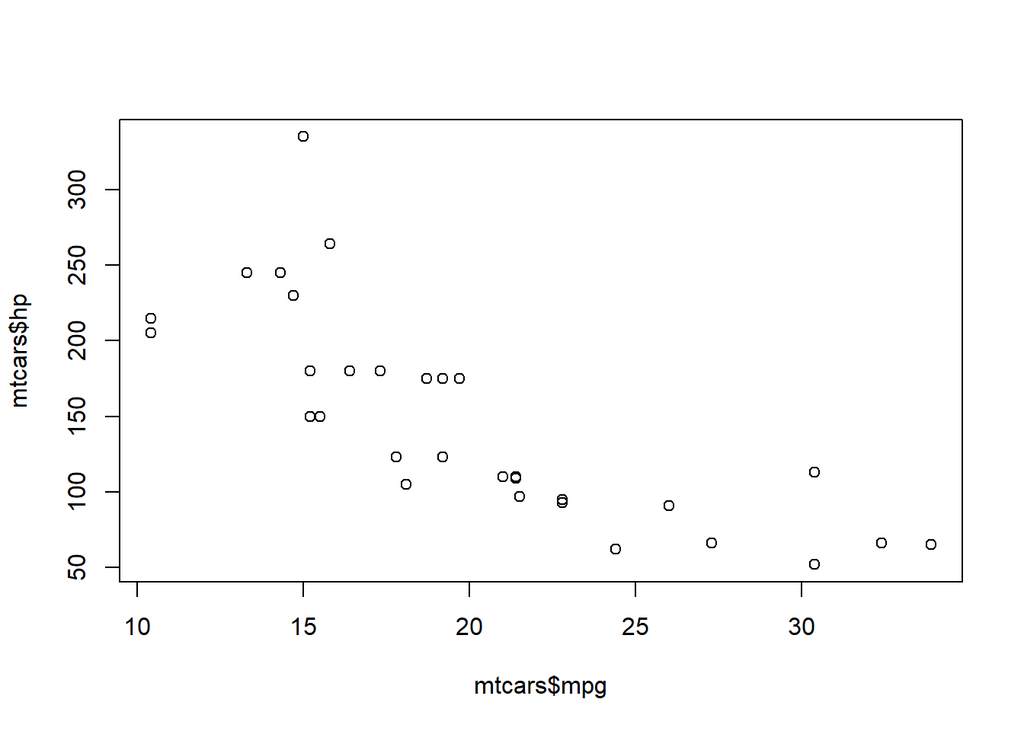

```r
# scatter plot of mpg vs hp from mtcars data set
plot(x = mtcars$mpg,
     y = mtcars$hp)
```

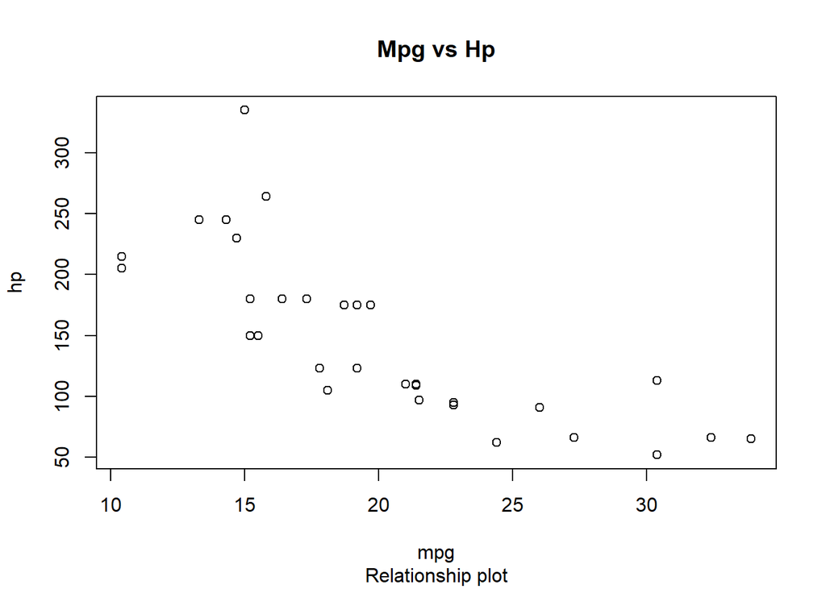

```r
# Adding labels
plot(x = mtcars$mpg,
     y = mtcars$hp,
     main = 'Mpg vs Hp',
     xlab = 'mpg', ylab = 'hp',
     sub = "Relationship plot")
```

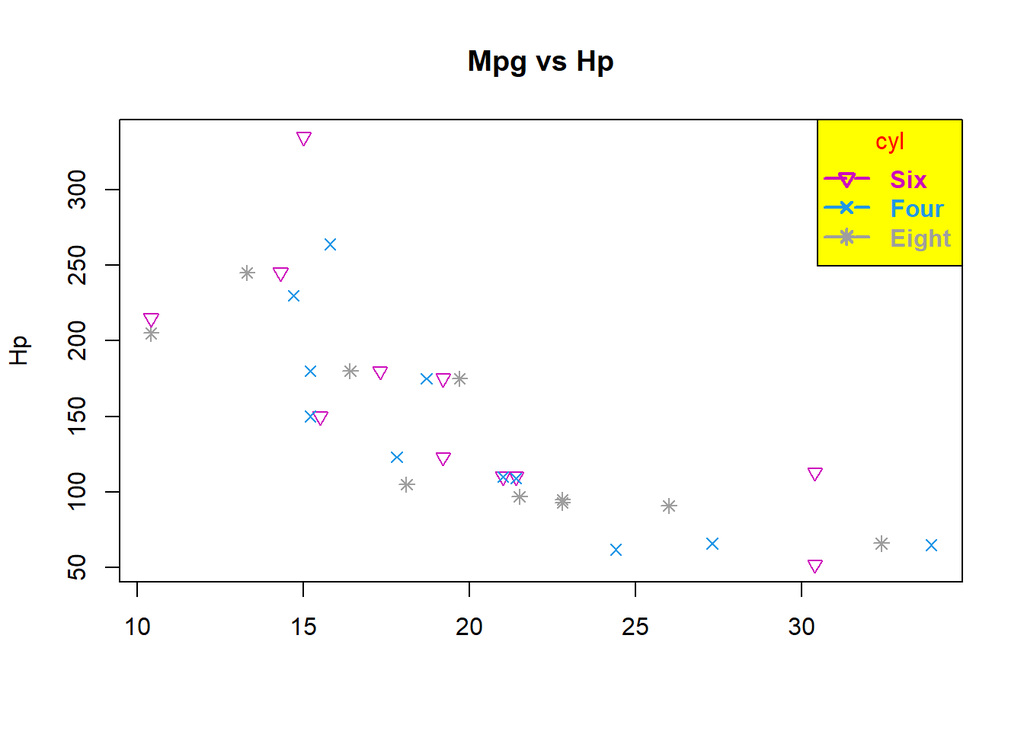

```r
# Adding colors and styles
plot(x = mtcars$mpg,
     y = mtcars$hp,
     main = 'Mpg vs Hp',
     xlab = '', ylab = 'Hp',
     pch = unique(mtcars$cyl),
     col = unique(mtcars$cyl))

# Adding legend
legend('topright', # legend position
       #locator(1), # legend position using mouse
       legend = c('Six','Four','Eight'),  # legend text
       col = unique(mtcars$cyl), # adding styles colors
       lty = 5, # adding line type
       lwd = 2, # adding line width
       title = 'cyl', # adding title of legend
       title.col = 'red',  # adding title color
       text.col = unique(mtcars$cyl), # adding text color
       bg = 'yellow', # adding background color
       text.font = 2, # changing text styles
       horiz = FALSE, # style of legend either horizontal or vertical
       pch = unique(mtcars$cyl) # adding plotted values style
       )
```

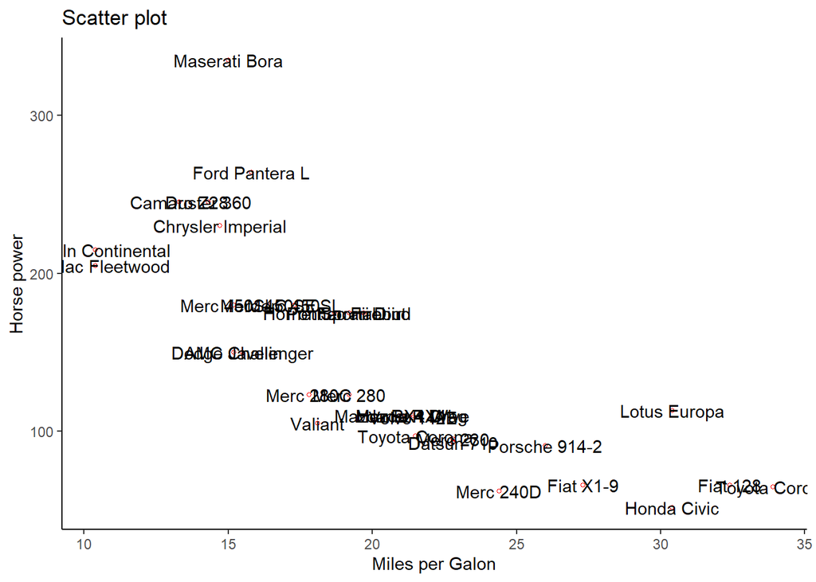

```r
# Scatter plot using ggplot2
ggplot(data = mtcars, aes(x = mpg, y = hp))+
    geom_point(shape=1, size=1, color='red')+ # adding points, colors and shapes
    labs(title = "Scatter plot", x = 'Miles per Galon', y = 'Horse power')+ # adding labels
    geom_text(label = row.names(mtcars))+ # adding points names
    theme_classic() # Removing background
```

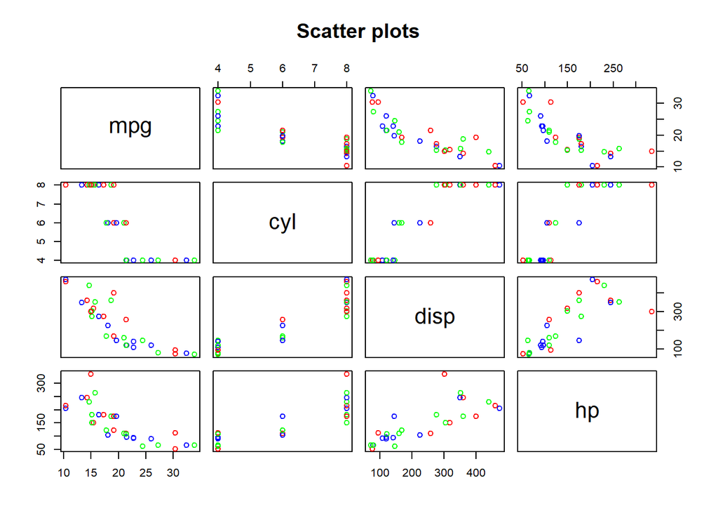

```r
# multiple groups
plot(mtcars[,1:4],
     main = "Scatter plots",
     col = rainbow(3))
```